# Linear Regression (Lab-11)

Bibek Sapkota

# Linear Regression

task 1:Loading the dataset

```r
dataset = read.csv("data-marketing-budget-12mo.csv")
dataset
```

| Month | Spend | Sales |
| --- | --- | --- |
| 1 | 1000 | 9914 |
| 2 | 4000 | 40487 |
| 3 | 5000 | 54324 |
| 4 | 4500 | 50044 |
| 5 | 3000 | 34719 |
| 6 | 4000 | 42551 |
| 7 | 9000 | 94871 |
| 8 | 11000 | 118914 |
| 9 | 15000 | 158484 |
| 10 | 12000 | 131348 |

[output cut: 2 more lines]

## Use ggplot to plot a scatter plot between variables

```r
library(ggplot2)

ggplot(data = dataset, aes(x = Sales, y = Spend)) + geom_point(alpha= 0.3, color= "blue")
```

[figure not shown]

## Q1:Write a command to plot sales for each month?

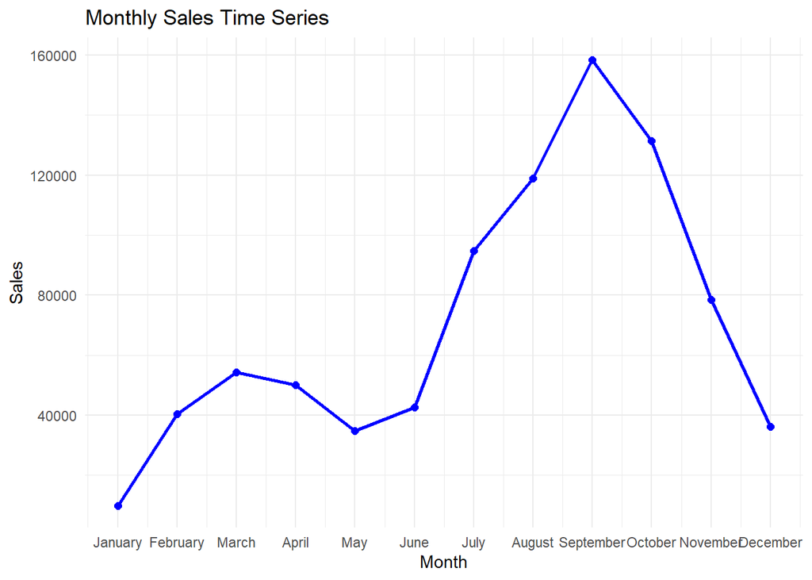

```r
ggplot(data = dataset, aes(x = Month, y = Sales)) +
  geom_line(color = "blue", size = 1) +
  geom_point(color = "blue", size = 2) +
  scale_x_continuous(breaks = 1:12, labels = month.name) +
  labs(title = "Monthly Sales Time Series", x = "Month", y = "Sales") +
  theme_minimal()
```

## Simple (One Variable) and Multiple Linear Regression

Using lm()

### One variable:

```r
simple.fit = lm(Sales~Spend, data=dataset)
summary(simple.fit)
```

```
##
## Call:
## lm(formula = Sales ~ Spend, data = dataset)
##
## Residuals:
##    Min     1Q Median     3Q    Max
##  -3385  -2097    258   1726   3034
##
## Coefficients:
##              Estimate Std. Error t value Pr(>|t|)
## (Intercept) 1383.4714  1255.2404   1.102    0.296
## Spend         10.6222     0.1625  65.378 1.71e-14 ***
## ---
## Signif. codes:  0 '***' 0.001 '**' 0.01 '*' 0.05 '.' 0.1 ' ' 1
##
## Residual standard error: 2313 on 10 degrees of freedom
## Multiple R-squared:  0.9977, Adjusted R-squared:  0.9974
## F-statistic:  4274 on 1 and 10 DF,  p-value: 1.707e-14
```

### Multiple variables:

```r
multi.fit = lm(Sales~Spend+Month, data=dataset)
summary(multi.fit)
```

```
##
## Call:
## lm(formula = Sales ~ Spend + Month, data = dataset)
##
## Residuals:
##      Min       1Q   Median       3Q      Max
## -1793.73 -1558.33    -1.73  1374.19  1911.58
##
## Coefficients:
##              Estimate Std. Error t value Pr(>|t|)
## (Intercept) -567.6098  1041.8836  -0.545  0.59913
## Spend         10.3825     0.1328  78.159 4.65e-14 ***
## Month        541.3736   158.1660   3.423  0.00759 **
## ---
## Signif. codes:  0 '***' 0.001 '**' 0.01 '*' 0.05 '.' 0.1 ' ' 1
##
## Residual standard error: 1607 on 9 degrees of freedom
## Multiple R-squared:  0.999,  Adjusted R-squared:  0.9988
## F-statistic:  4433 on 2 and 9 DF,  p-value: 3.368e-14
```

## Interpreting R’s Regression Output

task 1: Display each: # capture model summary as an object

```r
modelSummary <- summary(simple.fit)
```

task 2: model coefficients

```r
modelCoeffs <- modelSummary$coefficients
```

task 3: get beta estimate for Spend - 10.6222

```r
beta.estimate <- modelCoeffs["Spend", "Estimate"]
```

task 4: get std.error for Spend - 0.1624745

```r
std.error <- modelCoeffs["Spend", "Std. Error"]
```

task 6: get t value for Spend - 65.37761

```r
t_value <- modelCoeffs["Spend", "t value"]
```

task 7: get model F-statistic - 4274 1 10

```r
f <- modelSummary$fstatistic
f_statistic <- modelSummary$fstatistic[1]
```

task 8: get model p-value - 1.707e-14

```r
model_p <- pf(f[1], f[2], f[3], lower=FALSE)
```

task 9:get model R-squared - 0.9976659

```r
r_2 <- modelSummary$r.squared
```

## Q2: Based on residual, which model is better? Why?

Ans- Based on residual Multiple Regression Output is better beacuse it has less error.

## Q3: Try to write the multiple regression equation based on the numbers in the output (round to 1 decimal place).

Ans- Sales= 10.4 ⋅ Spend + 541.4 ⋅ Month − 567.6

## R2 abd residual

task 1:Loading data and creating linear regression and ploting the result

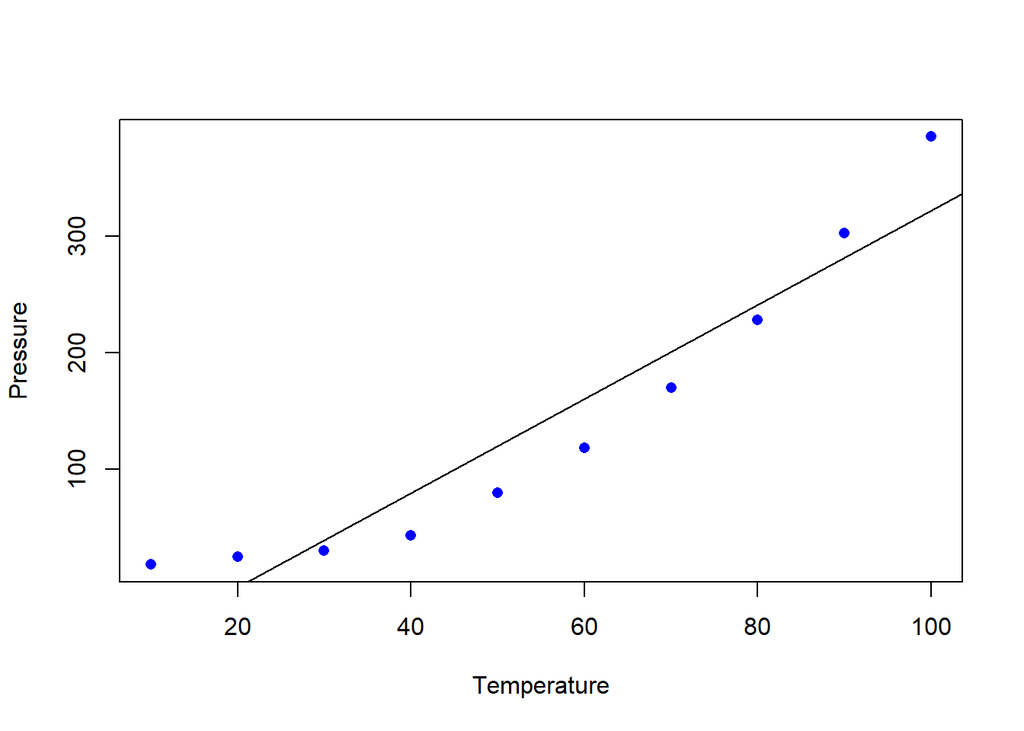

```r
library(readxl)

pressure <- read_excel("pressure.xlsx") #Upload the data
lmTemp = lm(Pressure~Temperature, data = pressure) #Create the linear regression
plot(pressure, pch = 16, col = "blue") #Plot the results
abline(lmTemp) #Add a regression line
```

task 2: Summarizing the lmTemp

```r
summary(lmTemp)
```

```
##
## Call:
## lm(formula = Pressure ~ Temperature, data = pressure)
##
## Residuals:
##    Min     1Q Median     3Q    Max
## -41.85 -34.72 -10.90  24.69  63.51
##
## Coefficients:
##             Estimate Std. Error t value Pr(>|t|)
## (Intercept) -81.5000    29.1395  -2.797   0.0233 *
## Temperature   4.0309     0.4696   8.583 2.62e-05 ***
## ---
## Signif. codes:  0 '***' 0.001 '**' 0.01 '*' 0.05 '.' 0.1 ' ' 1
##
## Residual standard error: 42.66 on 8 degrees of freedom
## Multiple R-squared:  0.902,  Adjusted R-squared:  0.8898
## F-statistic: 73.67 on 1 and 8 DF,  p-value: 2.622e-05
```

task 3: ploting the residuals, use the command plot(lmTemp$residuals).

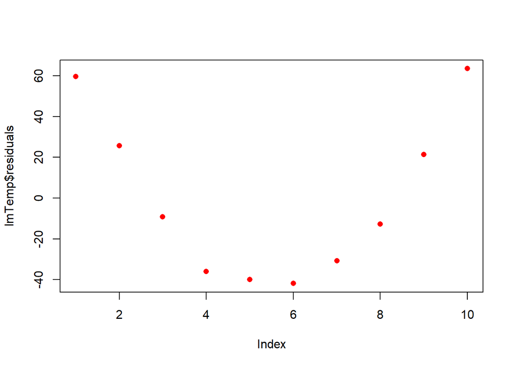

```r
plot(lmTemp$residuals, pch = 16, col = "red")
```

task 4: Printing the residuals in histogram

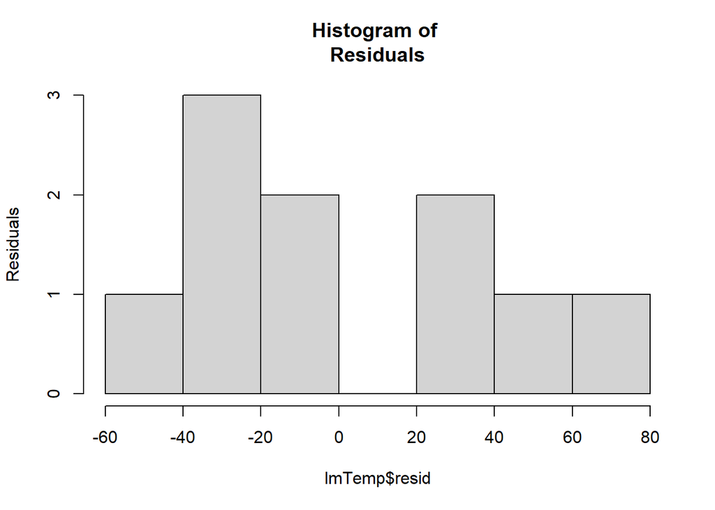

```r
hist(lmTemp$resid, main="Histogram of
Residuals", ylab="Residuals")
```

## Use linear regression to predict:

```r
a <- data.frame(Temperature = 170)
result <- predict(lmTemp,a)
print(result)
```

```
##        1
## 603.7545
```

## Q4: Use the linear regression to predict the pressure for temperature 40. Write your result.

```r
a <- data.frame(Temperature = 40)
result <- predict(lmTemp,a)
print(result)
```

```
##        1
## 79.73636
```

Ans- The prediction of the pressure for temperature 40 is 79.73636

## Linear regression to impute missing values:

task 1: Giving the value of x,y,z and w

```r
x <- 1:10
y <- c(11,12,18,14,17, NA,NA,19,NA,27)
z <- sample(1:20, 10)
w <- c(seq(1,10,3), 3,5,7,6,6,9)
```

task 2: Loading data into dataset

```r
data <- data.frame(x,y,z,w)
data
```

| x | y | z | w |
| --- | --- | --- | --- |
| 1 | 11 | 7 | 1 |
| 2 | 12 | 5 | 4 |
| 3 | 18 | 15 | 7 |
| 4 | 14 | 14 | 10 |
| 5 | 17 | 16 | 3 |
| 6 | NA | 10 | 5 |
| 7 | NA | 20 | 7 |
| 8 | 19 | 8 | 6 |
| 9 | NA | 18 | 6 |
| 10 | 27 | 12 | 9 |

task 3: Summarizing the data

```r
summary(data)
```

```
##        x               y               z               w
##  Min.   : 1.00   Min.   :11.00   Min.   : 5.00   Min.   : 1.00
##  1st Qu.: 3.25   1st Qu.:13.00   1st Qu.: 8.50   1st Qu.: 4.25
##  Median : 5.50   Median :17.00   Median :13.00   Median : 6.00
##  Mean   : 5.50   Mean   :16.86   Mean   :12.50   Mean   : 5.80
##  3rd Qu.: 7.75   3rd Qu.:18.50   3rd Qu.:15.75   3rd Qu.: 7.00
##  Max.   :10.00   Max.   :27.00   Max.   :20.00   Max.   :10.00
##                  NA's   :3
```

## Creating a dummy variable that will indicate missing data:

```r
missDummy <- function(t)
{
x <- dim(length(t))
x[which(!is.na(t))] = 1
x[which(is.na(t))] = 0
return(x)
}
data$dummy <- missDummy(data$y)
data
```

| x | y | z | w | dummy |
| --- | --- | --- | --- | --- |
| 1 | 11 | 7 | 1 | 1 |
| 2 | 12 | 5 | 4 | 1 |
| 3 | 18 | 15 | 7 | 1 |
| 4 | 14 | 14 | 10 | 1 |
| 5 | 17 | 16 | 3 | 1 |
| 6 | NA | 10 | 5 | 0 |
| 7 | NA | 20 | 7 | 0 |
| 8 | 19 | 8 | 6 | 1 |
| 9 | NA | 18 | 6 | 0 |
| 10 | 27 | 12 | 9 | 1 |

task 2: Next let us split data to 2sets (train and test):

```r
TrainData<- data[data['dummy']==1,]
TestData<- data[data['dummy']==0,]

TrainData<- TrainData[,-5]
TestData<- TestData[,-5]
```

task 3: Let’s then fit a linear model with y as dependent variable and x as independent variable.

```r
model<- lm(y~x, TrainData)
```

task 4: Predict missing values based on the model:

```r
pred<- predict(model, TestData)
pred
```

```
##        6        7        9
## 18.79730 20.30631 23.32432
```

task 5:Insert it back in the original

```r
# Where are NAs?
data$y[is.na(y)]
```

```
## [1] NA NA NA
```

```r
# Replace with predicted
data$y[is.na(y)]<- pred
```